# Group comparisons - single gene and total DE

Arjan Boltjes

17/01/2019

## Introduction

To check whether the gene expression of OSMR and/or LIFR differ, we performed two types of logistic regression, and additionaly performed differential expression analysis for the entire gene set used, from which we can then filter OSMR/LIFR.

In order for the second part to work, make sure you ran the following two files, saved the df’s and loaded them here:  
First, run: RNAseq_analysis_part_1_import_and_tidy.Rmd  
Second, run: RNAseq_analysis_part_2_AE.Rmd

```r
load("df.R")
load("metadata.R")
```

```r
library(haven)
library(tidyverse)
library(GenomicRanges)
library(SummarizedExperiment)
library(DESeq2)
library(pheatmap)
library(RColorBrewer)
library(PoiClaClu)
library(ggplot2)
library(reshape2)
library(org.Hs.eg.db)
library(cowplot)
library(MASS)
library(nnet)
```

## Data import, tidying, and selection

From the first Rmd file, we obtain a dataframe ‘df’ containing expression values of 25,441 genes, including chromosome, strand, and other locational information. The second Rmd file yields the ae dataframe containing all Athero-Express clinical data. We need to put all of this together (expression = assay part, clinical data = metadata part) and make sure to include the vulnerability and genotype in the metadata.

```r
# Cut up df into 'assay' and 'ranges' part
counts <- as.data.frame(df[,-(1:6)])              ## assay part
rownames(counts) <- df$gene_ensembl               ## assign rownames
rowRanges <- GRanges(df$chr,                    ## construct a GRanges object containing 4 columns (seqnames, ranges, strand, seqinfo) plus a metadata colum (feature_id): this will be the 'rowRanges' bit
                     IRanges(df$start, df$end),
                     strand = df$strand,
                     feature_id = df$gene_ensembl) #, df$pid)


metadata <- as.data.frame(metadata)

# Import and tidy vulnerability
path1 <- "F:\\Werk\\Cardio\\Athero-Express\\RNAseq pilot\\OSMR-LIFR (Danielle)\\20181129 Merge Chromosome 5 and vulnerability.sav"
vulnerability <- read_sav(path1)

# names(vulnerability) %<>%
#      tolower %>%
#      print

vulnerability %<>%
     rename_all(tolower) %>%
     mutate_at(vars(c("study_number")), funs(as.numeric)) %>%
     mutate_at(vars(c("stability", "rs10491509", "rs13168867")), funs(as.factor)) %>%
     mutate_at(vars(rs13168867), funs(factor(rs13168867, levels = c("TT", "CT", "CC", "")))) %>%
     mutate_at(vars(rs10491509), funs(factor(rs10491509, levels = c("GG", "AG", "AA", "00", "")))) %>%
     dplyr::select(study_number, rs10491509, rs13168867, stability) %>%
     mutate(study_number = str_replace(study_number, "([0-9]+)", "ae\\1"))

## vulnerability: subset only patients that are in our pilot RNA-seq data and add to metadata
metadata <- left_join(metadata, vulnerability, by = c("study_number" = "study_number"))

rownames(metadata) <- metadata$study_number
```

Do the study numbers correspond between metadata and expression data?

```r
## check whether rownames metadata and colnames counts are identical
all(rownames(metadata) == colnames(counts))
```

```
## [1] TRUE
```

SummarizedExperiment: container that brings all data together

```r
(se <- SummarizedExperiment(assays = list(counts = as.matrix(counts)),  ## as.matrix() is important here, to get dimnames the same (?) - see error below if you don't use this
                            rowRanges = rowRanges, colData = metadata)   )
```

```
## class: RangedSummarizedExperiment
## dim: 25441 30
## metadata(0):
## assays(1): counts
## rownames(25441): ENSG00000121410 ENSG00000268895 ...
##   ENSG00000074755 ENSG00000036549
## rowData names(1): feature_id
## colnames(30): ae1267 ae1343 ... ae2388 ae936
## colData names(892): study_number upid ... rs13168867 stability
```

So, now we have raw counts for the 30 patients included in the pilot RNAseq data, with all clinical data annotated to them, most importantly vulnerability.

Some of the patients might be missing in the vulnerability data. Checking this for stability, rs13168867, and rs10491509 respectively:

```r
# Vulnerability
# We know that one of the patients of the RNAseq is not included in the vulnerability set
which(is.na(se$stability))
```

```
## [1] 11
```

```r
which(is.na(se$rs13168867))
```

```
## [1] 11
```

```r
which(is.na(se$rs10491509))
```

```
## [1] 11
```

It turns out, that for all three variables the 11th patient is missing vulnerability data. Therefore, we removed this patient, and further analyzed the data.

```r
(se <- se[, -11])
```

```
## class: RangedSummarizedExperiment
## dim: 25441 29
## metadata(0):
## assays(1): counts
## rownames(25441): ENSG00000121410 ENSG00000268895 ...
##   ENSG00000074755 ENSG00000036549
## rowData names(1): feature_id
## colnames(29): ae1267 ae1343 ... ae2388 ae936
## colData names(892): study_number upid ... rs13168867 stability
```

# Analyze gene expression differences between groups

From here we can analyze whether specific genes differ between groups, or do this for the entire gene set as part of DE analysis, and then select our genes of interest. Let’s start with the former.

The dds raw counts need normalization and log transformation frst.

```r
dds <- DESeqDataSet(se, design = ~ 1)

# Determine the size factors to use for normalization
dds <- estimateSizeFactors(dds)
# sizeFactors(dds)

# Extract the normalized counts
normalized_counts <- counts(dds, normalized = TRUE)
# head(normalized_counts)

# Log transform counts for QC
vsd <- vst(dds, blind = TRUE)
```

From here, extract the gene expression values, plus gene identifier, annotate with gene symbol, and select the genes of our interest: OSMR and LIFR.

```r
expression_data <- assay(vsd)


# extract expression values from vsd, including ensembl names
expression_data <- as_tibble(data.frame(gene_ensembl = rowRanges(vsd)$feature_id, assay(vsd))) %>%
     mutate_at(vars(c("gene_ensembl")), funs(as.character)) ## gene_ensembl needs to be character for annotation to work

# annotations
# gene symbol - via org.Hs.eg.db
# columns(org.Hs.eg.db)
expression_data$symbol <- mapIds(org.Hs.eg.db,
                    keys = expression_data$gene_ensembl,
                    column = "SYMBOL",
                    keytype = "ENSEMBL",
                    multiVals = "first")

# tidy and subset OSMR and LIFR
expression_data %<>%
     dplyr::select(gene_ensembl, symbol, everything()) %>%
     filter(symbol == "OSMR" | symbol == "LIFR") %>%
     print
```

```
## # A tibble: 2 x 31
##   gene_ensembl symbol ae1267 ae1343 ae1373 ae1374 ae1376 ae1407 ae1504
##   <chr>        <chr>   <dbl>  <dbl>  <dbl>  <dbl>  <dbl>  <dbl>  <dbl>
## 1 ENSG0000011~ LIFR     4.46   4.89   4.30   6.01   5.06   5.64   5.31
## 2 ENSG0000014~ OSMR     5.93   5.53   6.04   5.80   4.30   4.30   6.12
## # ... with 22 more variables: ae1858 <dbl>, ae1932 <dbl>, ae2117 <dbl>,
## #   ae2419 <dbl>, ae2555 <dbl>, ae2611 <dbl>, ae696 <dbl>, ae904 <dbl>,
## #   ae947 <dbl>, ae1029 <dbl>, ae1140 <dbl>, ae1390 <dbl>, ae1413 <dbl>,
## #   ae1831 <dbl>, ae1938 <dbl>, ae2009 <dbl>, ae2149 <dbl>, ae2195 <dbl>,
## #   ae2208 <dbl>, ae2318 <dbl>, ae2388 <dbl>, ae936 <dbl>
```

Furthermore, the expression_data df was gathered into a long form df for annotation with vulnerability variables from vsd object, and later visualization and statistics.

```r
# gather expression_data df into long df form for annotation, plotting and statistics
expression_long <-
     gather(expression_data, key = "patient", value = "expression_value", -c(gene_ensembl, symbol)) %>%
     arrange(symbol)

# Annotate with vulnerability and genotype
sample_ids <- expression_long$patient
mm <- match(expression_long$patient, rownames(colData(vsd)))

## Add traits to df
## Binary traits
expression_long$stability <- colData(vsd)$stability[mm]
expression_long$rs10491509 <- colData(vsd)$rs10491509[mm]
expression_long$rs13168867 <- colData(vsd)$rs13168867[mm]

expression_long
```

```
## # A tibble: 58 x 7
##    gene_ensembl symbol patient expression_value stability rs10491509
##    <chr>        <chr>  <chr>              <dbl> <fct>     <fct>
##  1 ENSG0000011~ LIFR   ae1267              4.46 2         AG
##  2 ENSG0000011~ LIFR   ae1343              4.89 1         AA
##  3 ENSG0000011~ LIFR   ae1373              4.30 1         AG
##  4 ENSG0000011~ LIFR   ae1374              6.01 2         GG
##  5 ENSG0000011~ LIFR   ae1376              5.06 1         AG
##  6 ENSG0000011~ LIFR   ae1407              5.64 2         GG
##  7 ENSG0000011~ LIFR   ae1504              5.31 2         GG
##  8 ENSG0000011~ LIFR   ae1858              5.58 3         AG
##  9 ENSG0000011~ LIFR   ae1932              4.99 2         00
## 10 ENSG0000011~ LIFR   ae2117              5.02 2         GG
## # ... with 48 more rows, and 1 more variable: rs13168867 <fct>
```

# Visualizing OSMR and LIFR expression

Since for the earlier report we did not log transform the data, hereby a selection of the plots made with the current data analysis.

**Figure 1: collecting figures 7-9 and 13-15 from last report**

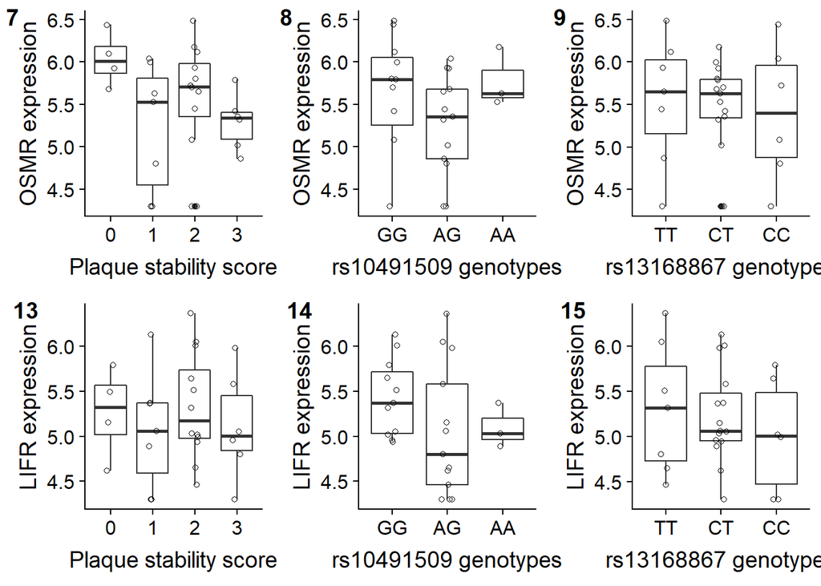

```r
# Subset OSMR
ggdf_OSMR <- expression_long[expression_long$symbol == "OSMR",] %>%
     mutate_at(vars(stability), funs(droplevels.factor))

# Plot against stability scores
OSMR_stab <- ggplot(ggdf_OSMR, aes(x = stability, y = expression_value)) +
     geom_boxplot() +
     geom_jitter(width = 0.1, shape = 1) +
     xlab("Plaque stability score") +
     ylab("OSMR expression")

# Plot against rs10491509 genotypes
OSMR_rs104 <- ggplot(subset(ggdf_OSMR, rs10491509 == "AA" | rs10491509 == "AG" | rs10491509 == "GG"), aes(x = rs10491509, y = expression_value)) +
     geom_boxplot() +
     geom_jitter(width = 0.1, shape = 1) +
     xlab("rs10491509 genotypes") +
     ylab("OSMR expression")

# Plot against rs13168867 genotypes
OSMR_rs131 <- ggplot(subset(ggdf_OSMR, rs13168867 == "CC" | rs13168867 == "CT" | rs13168867 == "TT"), aes(x = rs13168867, y = expression_value)) +
     geom_boxplot() +
     geom_jitter(width = 0.1, shape = 1) +
     xlab("rs13168867 genotypes") +
     ylab("OSMR expression")

# Subset LIFR
ggdf_LIFR <- expression_long[expression_long$symbol == "LIFR",] %>%
     mutate_at(vars(stability), funs(droplevels.factor))

# Plot against stability scores
LIFR_stab <- ggplot(ggdf_LIFR, aes(x = stability, y = expression_value)) +
     geom_boxplot() +
     geom_jitter(width = 0.1, shape = 1) +
     xlab("Plaque stability score") +
     ylab("LIFR expression")

# Plot against rs10491509 genotypes
LIFR_rs104 <- ggplot(subset(ggdf_LIFR, rs10491509 == "AA" | rs10491509 == "AG" | rs10491509 == "GG"), aes(x = rs10491509, y = expression_value)) +
     geom_boxplot() +
     geom_jitter(width = 0.1, shape = 1) +
     xlab("rs10491509 genotypes") +
     ylab("LIFR expression")

# Plot against rs13168867 genotypes
LIFR_rs131 <- ggplot(subset(ggdf_LIFR, rs13168867 == "CC" | rs13168867 == "CT" | rs13168867 == "TT"), aes(x = rs13168867, y = expression_value)) +
     geom_boxplot() +
     geom_jitter(width = 0.1, shape = 1) +
     xlab("rs13168867 genotypes") +
     ylab("LIFR expression")

plot_grid(OSMR_stab, OSMR_rs104, OSMR_rs131, LIFR_stab, LIFR_rs104, LIFR_rs131, labels = c("7", "8", "9", "13", "14", "15"))
```

Please note that due to the transformation the y-axis values are different than before, while the overall figure shape and data trend are similar, as you would expect.

# Ordinal logistic regression for stability

Since the outcome variable (stability) is categorized AND ordered, I chose to use ordinal logistic regression in this case.

**OSMR**  
View a summary of the model

```r
## fit ordered logit model and store results 'm'
m <- polr(stability ~ expression_value, data = ggdf_OSMR, Hess = TRUE)

## view a summary of the model
summary(m)
```

```
## Call:
## polr(formula = stability ~ expression_value, data = ggdf_OSMR,
##     Hess = TRUE)
##
## Coefficients:
##                    Value Std. Error t value
## expression_value -0.4844     0.5327 -0.9092
##
## Intercepts:
##     Value   Std. Error t value
## 0|1 -4.5026  3.0066    -1.4976
## 1|2 -3.1453  2.9555    -1.0642
## 2|3 -1.2957  2.9325    -0.4418
##
## Residual Deviance: 74.98032
## AIC: 82.98032
```

Calculate p-values

```r
## calculate p values
## store table
ctable <- coef(summary(m))

## calculate and store p values
p <- pnorm(abs(ctable[, "t value"]), lower.tail = FALSE) * 2

## combined table
(ctable <- cbind(ctable, "p value" = p))
```

```
##                       Value Std. Error    t value   p value
## expression_value -0.4843821  0.5327464 -0.9092170 0.3632356
## 0|1              -4.5026276  3.0066460 -1.4975583 0.1342481
## 1|2              -3.1453412  2.9555268 -1.0642235 0.2872274
## 2|3              -1.2956641  2.9324834 -0.4418317 0.6586110
```

Assess confidence intervals (CI’s) for the parameter estimates.

Method 1: profiling the likelihood function

```r
# profiling the likelihood function
(ci <- confint(m)) # default method gives profiled CIs
```

```
##      2.5 %     97.5 %
## -1.5821084  0.5355575
```

Method 2: assuming normality

```r
confint.default(m) # CIs assuming normality
```

```
##                      2.5 %    97.5 %
## expression_value -1.528546 0.5597817
```

**Interpreting statistics**  
When assessing above statistical approach, we can conclude the following: there is no difference between OSMR expression values between consecutive stability scores, based on p-values (none below 0.05) and CI’s (CI crosses zero).

Note however, that for ordinal logistic regression the assumption is that the relationship between each pair of outcome groups is the same. This is called the proportional odds assumption. When assessing this, I’m not so sure whether the data fits this assumption.

An alternative approach is using multinomial logistic regression for stability, assuming that the categoris of the outcome variable (plaque stability) are not ordered.

# Multinomial logistic regression for stability

**OSMR**  
View a summary of the model

```r
# model
ggdf_OSMR$stability_2 <- relevel(ggdf_OSMR$stability, ref = "0") ## not needed, since 0 is already the first level, and is automatically used as baseline
test <- multinom(stability ~ expression_value, data = ggdf_OSMR)
## view a summary of the model
summary(test)
```

```
## Call:
## multinom(formula = stability ~ expression_value, data = ggdf_OSMR)
##
## Coefficients:
##   (Intercept) expression_value
## 1    20.20868        -3.435304
## 2    15.84396        -2.527286
## 3    19.16851        -3.266924
##
## Std. Errors:
##   (Intercept) expression_value
## 1    10.78562         1.829239
## 2    10.36639         1.738708
## 3    10.83666         1.838029
##
## Residual Deviance: 69.44177
## AIC: 81.44177
```

Calculate p-values using Wald (z) tests

```r
## calculate p values
z <- summary(test)$coefficients/summary(test)$standard.errors
z
```

```
##   (Intercept) expression_value
## 1    1.873669        -1.877996
## 2    1.528396        -1.453543
## 3    1.768858        -1.777407
```

Because the Wald statistic is asymptotically distributed as a standard normal distribution, we can use the z-score to calculate the p-value.

```r
# 2-tailed z test
p <- (1 - pnorm(abs(z), 0, 1)) * 2
p
```

```
##   (Intercept) expression_value
## 1  0.06097611       0.06038173
## 2  0.12641416       0.14607315
## 3  0.07691753       0.07550137
```

**Interpreting statistics**  
When looking at the above statistics, in the end the p-values are in the last column. These are p-values for the comparison of OSMR expression values of one of the row denominators (1, 2 or 3, i.e. scores 1-3) and expression values of our baseline stability score 0.

Although non are significant (<0.05), they are close to it, and they follow the general trend that we saw in the boxplot for OSMR expression vs. stability scores.

# Differential expression

Since this gene analyis is now focused on OSMR and stability, we can be short about differential expression (DE) of the entire dataset, where we analyze DE of all genes between either stability score 0 and 1, 0 and 2, 0 and 3, 1 and 2, 1 and 3, or 2 and 3.

None of these comparisons yielded any DE genes, including OSMR and LIFR. We did find a few DE genes when comparing DE between genotypes of rs13168867, but also here OSMR and LIFR were not included.

In order to not make this document any longer, DE analyses are in a separate R script.